# My First R Markdown File

This is my first Markdown file to look at data

**Loading and preprocessing the data**

```r
csvRaw <-read.csv("data/activity.csv")
omittedNA <-na.omit(csvRaw)
#rm(csvRaw)
head(omittedNA,5)
```

```
##     steps       date interval
## 289     0 2012-10-02        0
## 290     0 2012-10-02        5
## 291     0 2012-10-02       10
## 292     0 2012-10-02       15
## 293     0 2012-10-02       20
```

```r
totalRows<-nrow(omittedNA)
```

Total rows of data after we omit NA’s is 15,264.

**What is mean total number of steps taken per day?**

```r
sumByDate<-aggregate(omittedNA$steps~omittedNA$date,FUN=sum)
names(sumByDate)<-c("date","steps")
mean_total_steps_count<-nrow(sumByDate)
```

The total number of rows from the aggregate of steps ~ date is 53.

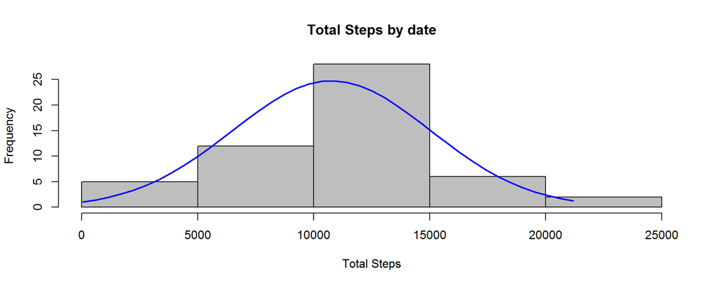

```r
x<-sumByDate$steps
myHist<-hist(x,xlab="Total Steps",main="Total Steps by date",col="gray")
xfit<-seq(min(x),max(x),length=40)
yfit<-dnorm(xfit,mean=mean(x),sd=sd(x))
yfit <- yfit*diff(myHist$mids[1:2])*length(x)
lines(xfit, yfit, col="blue", lwd=2)
```

*Mean & Median*

```r
theMean<-mean(x)
theMedian<-median(x)
theMean
```

```
## [1] 10766.19
```

```r
theMedian
```

```
## [1] 10765
```

The mean of the total steps by date is 10,766.19 and the median is 10,765.

*What is the average daily activity pattern?*

1. Make a time series plot (i.e. type = “l”) of the 5-minute interval (x-axis) and the average number of steps taken, averaged across all days (y-axis)

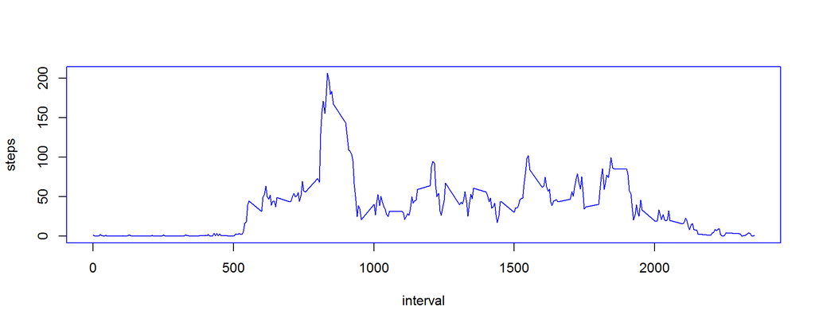

```r
steps_interval <- aggregate(steps ~ interval, data = omittedNA, FUN = mean)
par(pch=22, col="blue")
plot(steps_interval,type="l")
```

2. Which 5-minute interval, on average across all the days in the dataset, contains the maximum number of steps?

```r
max_steps<-steps_interval[which.max(steps_interval$steps),]
r_steps <- max_steps$steps
r_interval <- max_steps$interval
```

3. Create a new dataset that is equal to the original dataset but with the missing data filled in.

The 5-minute interval containing the maxium number of steps is interval 835 with 206.1698 steps.

```r
#csvRaw[is.na(csvRaw$steps)] <- mean(csvRaw$steps, na.rm = TRUE)
raw<-csvRaw
totalNonCompleteRows <-sum(!complete.cases(raw))
totalRawcount<-nrow(csvRaw)

raw$steps[is.na(raw$steps)] = mean(raw$steps, na.rm=TRUE)
raw$interval[is.na(raw$interval)] = mean(raw$interval, na.rm=TRUE)
countOfFilledIn<-nrow(raw)

omittedNARaw <-na.omit(raw)
CountOfFilledInWithoutNAs<-nrow(omittedNARaw)
#head(raw)
```

The original count of rows was 17,568, there are 2,304 incomplete rows in the orignal dataset.

We utilized the mean of the column as a replacement for any NAs of the column. The total number of rows after replacing all NAs with the mean of the column is 17,568.

To validate our results we performed a na.omit on the data frame and come up with 17,568 as its row count.

4. Make a histogram of the total number of steps taken each day and Calculate and report the mean and median total number of steps taken per day. Do these values differ from the estimates from the first part of the assignment? What is the impact of imputing missing data on the estimates of the total daily number of steps?

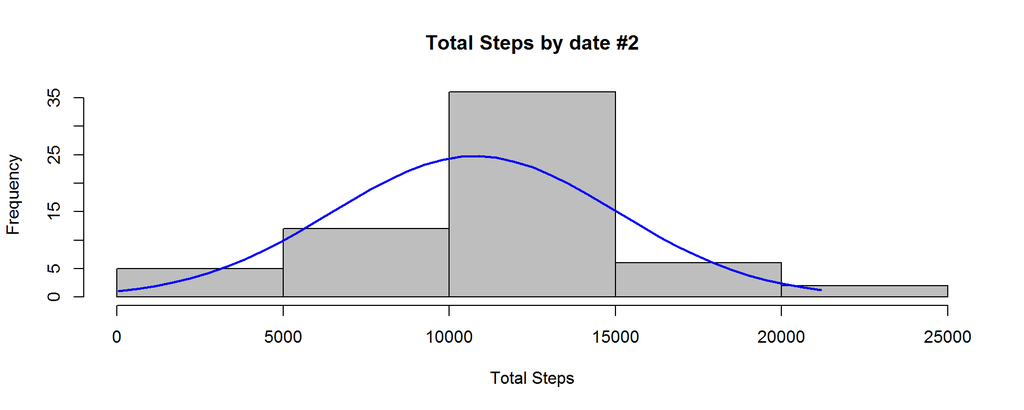

```r
sumByDate_noNAs<-aggregate(raw$steps~raw$date,FUN=sum)
names(sumByDate_noNAs)<-c("date","steps")

theNewMean <- mean(sumByDate_noNAs$steps)
theNewMedian <-median(sumByDate_noNAs$steps)


NaFilledHist<-hist(sumByDate_noNAs$steps,xlab="Total Steps",main="Total Steps by date #2",col="gray")
xfit<-seq(min(x),max(x),length=40)
yfit<-dnorm(xfit,mean=mean(x),sd=sd(x))
yfit <- yfit*diff(NaFilledHist$mids[1:2])*length(x)
lines(xfit, yfit, col="blue", lwd=2)
```

The original mean was 10,766.19 and the new mean is 10,766.19. The original median was 10,765 and the new median is 10,766.19.

```r
raw$weekdays<-weekdays(as.Date(raw$date))
raw[sample(nrow(raw),5),]
```

```
##       steps       date interval weekdays
## 13475    45 2012-11-16     1850   Friday
## 4227     58 2012-10-15     1610   Monday
## 4087      0 2012-10-15      430   Monday
## 7828      0 2012-10-28      415   Sunday
## 400       0 2012-10-02      915  Tuesday
```

```r
raw$wkndwkday<- as.factor(ifelse(raw$weekdays %in% c("Saturday","Sunday"), "Weekend", "Weekday"))
raw[sample(nrow(raw),5),]
```

```
##        steps       date interval  weekdays wkndwkday
## 14   37.3826 2012-10-01      105    Monday   Weekday
## 2340 50.0000 2012-10-09      255   Tuesday   Weekday
## 3809  0.0000 2012-10-14      520    Sunday   Weekend
## 2626  0.0000 2012-10-10      245 Wednesday   Weekday
## 6182 29.0000 2012-10-22     1105    Monday   Weekday
```